# AllLife Bank Customer Segmentation

### Context

Over the next financial year, AllLife Bank wants to focus on its credit card customer base. The Marketing Research Team has advised that penetration in the market can be improved. Based on this, the Marketing Team proposes to run personalized campaigns to target new customers and also upsell to existing customers.

Another insight was that the customers have a poor perception of the bank's support services. Based on this, the Operations Team wants to upgrade the service delivery model, to ensure that customer queries are resolved more quickly.

### Objective

- Identify different segments among existing customers, based on their spending patterns as well as past interaction with the bank, using clustering algorithms
- Provide recommendations to the bank on how to better market to and service these customers.

#### Methodology

- For cross-marketing purposes, it may make sense to identify the cluster with the least amount of credit cards for marketing new credit cards.
- It may also make sense to market credit cards to the cluster with the highest credit limit, since they will tend to have more money, and therefore be more desirable as clients.
- For targeting new customers, it would make sense to find the cluster with the highest credit limit, and identify the most common method of contact for this cluster. The company should place a heavy emphasis on marketing using that contact method.
- For improving service, it makes sense to find the largest cluster, identify their preferred method of contact, and focus on improving customer service for that method of contact.
- It would also make sense to focus on improving customer service for the method of contact of the clients with the highest credit limit. We want to make a concerted effort to retain our most important clients.

```python
# Importing libraries

# Standard libraries
import pandas as pd
import numpy as np
import matplotlib.pylab as plt
%matplotlib inline
import warnings
warnings.filterwarnings("ignore")
import seaborn as sns

# Clustering libraries
from sklearn.cluster import KMeans
from scipy.stats import zscore
from sklearn.cluster import AgglomerativeClustering
from scipy.cluster.hierarchy import cophenet, dendrogram, linkage
from scipy.spatial.distance import pdist
from scipy.spatial.distance import cdist
from sklearn.metrics import silhouette_score
from yellowbrick.cluster import KElbowVisualizer, SilhouetteVisualizer
```

```python
# Importing the file, and viewing the first 20 rows

credit = pd.read_excel("Credit Card Customer Data.xlsx")
df = credit.copy(deep=True)
df.head(20)
```

|  | Sl_No | Customer Key | Avg_Credit_Limit | Total_Credit_Cards | Total_visits_bank | Total_visits_online | Total_calls_made |
| --- | --- | --- | --- | --- | --- | --- | --- |
| 0 | 1 | 87073 | 100000 | 2 | 1 | 1 | 0 |
| 1 | 2 | 38414 | 50000 | 3 | 0 | 10 | 9 |
| 2 | 3 | 17341 | 50000 | 7 | 1 | 3 | 4 |
| 3 | 4 | 40496 | 30000 | 5 | 1 | 1 | 4 |
| 4 | 5 | 47437 | 100000 | 6 | 0 | 12 | 3 |
| 5 | 6 | 58634 | 20000 | 3 | 0 | 1 | 8 |
| 6 | 7 | 48370 | 100000 | 5 | 0 | 11 | 2 |
| 7 | 8 | 37376 | 15000 | 3 | 0 | 1 | 1 |
| 8 | 9 | 82490 | 5000 | 2 | 0 | 2 | 2 |
| 9 | 10 | 44770 | 3000 | 4 | 0 | 1 | 7 |
| 10 | 11 | 52741 | 10000 | 4 | 0 | 5 | 5 |
| 11 | 12 | 52326 | 13000 | 3 | 0 | 2 | 7 |
| 12 | 13 | 92503 | 11000 | 1 | 2 | 5 | 9 |
| 13 | 14 | 25084 | 9000 | 1 | 1 | 5 | 6 |
| 14 | 15 | 68517 | 6000 | 2 | 2 | 4 | 6 |
| 15 | 16 | 55196 | 8000 | 2 | 0 | 5 | 7 |
| 16 | 17 | 62617 | 15000 | 2 | 1 | 2 | 4 |
| 17 | 18 | 96463 | 8000 | 2 | 0 | 3 | 4 |
| 18 | 19 | 39137 | 11000 | 2 | 2 | 2 | 7 |
| 19 | 20 | 14309 | 19000 | 4 | 1 | 5 | 8 |

```python
# Identifying the shape of the data

df.shape
```

```
(660, 7)
```

```python
# 660 rows, 7 columns

# Running .info to ascertain data types and identify columns with missing values

df.info()
```

```
<class 'pandas.core.frame.DataFrame'>
RangeIndex: 660 entries, 0 to 659
Data columns (total 7 columns):
 #   Column               Non-Null Count  Dtype
---  ------               --------------  -----
 0   Sl_No                660 non-null    int64
 1   Customer Key         660 non-null    int64
 2   Avg_Credit_Limit     660 non-null    int64
 3   Total_Credit_Cards   660 non-null    int64
 4   Total_visits_bank    660 non-null    int64
 5   Total_visits_online  660 non-null    int64
 6   Total_calls_made     660 non-null    int64
dtypes: int64(7)
memory usage: 36.2 KB
```

### Data Dictionary

- Sl_No: Primary key of the records
  - I suspect that this variable is not statistically significant and will be dropped
- Customer Key: Customer identification number
  - This variable will also likely be dropped for the same reason
- Average Credit Limit: Average customer credit limit for all credit cards
- Total credit cards: Total number of credit cards possessed by the customer
- Total visits bank: Total number of in-person visits that customer made annually
- Total visits online: Total number of online logins/visits that the customer made annually
- Total calls made: Total number of calls that the customer made annually to the bank or its customer service department
- No missing values
- All variables are numeric

```python
# Checking for duplicate rows

df.duplicated().sum()
```

```
0
```

```python
# No rows are duplicated

# Running a preliminary statistical analysis

df.describe()
```

|  | Sl_No | Customer Key | Avg_Credit_Limit | Total_Credit_Cards | Total_visits_bank | Total_visits_online | Total_calls_made |
| --- | --- | --- | --- | --- | --- | --- | --- |
| count | 660.000000 | 660.000000 | 660.000000 | 660.000000 | 660.000000 | 660.000000 | 660.000000 |
| mean | 330.500000 | 55141.443939 | 34574.242424 | 4.706061 | 2.403030 | 2.606061 | 3.583333 |
| std | 190.669872 | 25627.772200 | 37625.487804 | 2.167835 | 1.631813 | 2.935724 | 2.865317 |
| min | 1.000000 | 11265.000000 | 3000.000000 | 1.000000 | 0.000000 | 0.000000 | 0.000000 |
| 25% | 165.750000 | 33825.250000 | 10000.000000 | 3.000000 | 1.000000 | 1.000000 | 1.000000 |
| 50% | 330.500000 | 53874.500000 | 18000.000000 | 5.000000 | 2.000000 | 2.000000 | 3.000000 |
| 75% | 495.250000 | 77202.500000 | 48000.000000 | 6.000000 | 4.000000 | 4.000000 | 5.000000 |
| max | 660.000000 | 99843.000000 | 200000.000000 | 10.000000 | 5.000000 | 15.000000 | 10.000000 |

#### Observations

```python
# Removing variables that aren't statistically significant

df.drop(["Sl_No", "Customer Key"], axis=1, inplace=True)

# Scaling data using z-scores

# This is necessary in clustering so that a variable with large numbers
# doesn't bias the distances

# Using z-scores will center the mean on 0, and change each value to the number
# of standard deviations the original value is away from the mean

dfScaled=df.apply(zscore)

# Confirming that dropped columns are gone, and z-scores exist for remaining
# columns

dfScaled.head(20)
```

|  | Avg_Credit_Limit | Total_Credit_Cards | Total_visits_bank | Total_visits_online | Total_calls_made |
| --- | --- | --- | --- | --- | --- |
| 0 | 1.740187 | -1.249225 | -0.860451 | -0.547490 | -1.251537 |
| 1 | 0.410293 | -0.787585 | -1.473731 | 2.520519 | 1.891859 |
| 2 | 0.410293 | 1.058973 | -0.860451 | 0.134290 | 0.145528 |
| 3 | -0.121665 | 0.135694 | -0.860451 | -0.547490 | 0.145528 |
| 4 | 1.740187 | 0.597334 | -1.473731 | 3.202298 | -0.203739 |
| 5 | -0.387644 | -0.787585 | -1.473731 | -0.547490 | 1.542593 |
| 6 | 1.740187 | 0.135694 | -1.473731 | 2.861408 | -0.553005 |
| 7 | -0.520633 | -0.787585 | -1.473731 | -0.547490 | -0.902271 |
| 8 | -0.786612 | -1.249225 | -1.473731 | -0.206600 | -0.553005 |
| 9 | -0.839808 | -0.325946 | -1.473731 | -0.547490 | 1.193326 |
| 10 | -0.653623 | -0.325946 | -1.473731 | 0.816070 | 0.494794 |
| 11 | -0.573829 | -0.787585 | -1.473731 | -0.206600 | 1.193326 |
| 12 | -0.627025 | -1.710864 | -0.247170 | 0.816070 | 1.891859 |
| 13 | -0.680221 | -1.710864 | -0.860451 | 0.816070 | 0.844060 |
| 14 | -0.760014 | -1.249225 | -0.247170 | 0.475180 | 0.844060 |
| 15 | -0.706819 | -1.249225 | -1.473731 | 0.816070 | 1.193326 |
| 16 | -0.520633 | -1.249225 | -0.860451 | -0.206600 | 0.145528 |
| 17 | -0.706819 | -1.249225 | -1.473731 | 0.134290 | 0.145528 |
| 18 | -0.627025 | -1.249225 | -0.247170 | -0.206600 | 1.193326 |
| 19 | -0.414242 | -0.325946 | -0.860451 | 0.816070 | 1.542593 |

```python
# Sometimes, missing values can be hidden as other values, such as 0
# I will check for these using value counts

print("Avg Credit Limit: \n",df.Avg_Credit_Limit.value_counts())
print("Total Credit Cards: \n",df.Total_Credit_Cards.value_counts())
print("Total Visits Bank: \n",df.Total_visits_bank.value_counts())
print("Total Visits Online: \n",df.Total_visits_online.value_counts())
print("Total Calls Made: \n",df.Total_calls_made.value_counts())
```

```
Avg Credit Limit:
 8000      35
6000      31
9000      28
13000     28
10000     26
          ..
25000      1
153000     1
111000     1
112000     1
106000     1
Name: Avg_Credit_Limit, Length: 110, dtype: int64
Total Credit Cards:
 4     151
```

[output cut: 49 more lines]

- Some 0 values in the last 3 variables.
- These variables are all for method of contact, and it can be reasonably assumed that these customers simply did not use that method of contact.
- Confirmed: there are no missing values

### EDA

#### Univariate

```python
# Function to create a combo boxplot/histogram with same x-axis.

def histogram_boxplot(data, feature, figsize=(12, 7), kde=False, bins=None):
    """
    Boxplot and histogram combined

    data: dataframe
    feature: dataframe column
    figsize: size of figure (default (12,7))
    kde: whether to the show density curve (default False)
    bins: number of bins for histogram (default None)
    """
    f2, (ax_box2, ax_hist2) = plt.subplots(
        nrows=2,
        sharex=True,  # x-axis will be shared
        gridspec_kw={"height_ratios": (0.25, 0.75)},
        figsize=figsize,
    )  # creating 2 subplots
    sns.boxplot(
        data=data, x=feature, ax=ax_box2, showmeans=True, color="violet"
    )  # star on mean value of the column for the boxplot
    sns.histplot(
        data=data, x=feature, kde=kde, ax=ax_hist2, bins=bins, palette="winter"
    ) if bins else sns.histplot(
        data=data, x=feature, kde=kde, ax=ax_hist2
    )
    ax_hist2.axvline(
        data[feature].mean(), color="green", linestyle="--"
    )  # Green line on mean for the histogram
    ax_hist2.axvline(
        data[feature].median(), color="black", linestyle="-"
    )  # Black line on median for the histogram
```

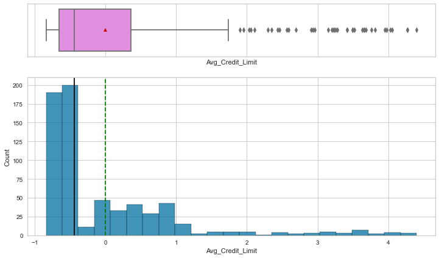

```python
histogram_boxplot(dfScaled, "Avg_Credit_Limit")
```

#### Observations

- As predicted, many high outliers. This is probably accurate data - a credit limit of 200,000 is high, but not unheard of
- In clustering, outliers don't necessarily need to be treated, as they may form their own unique cluster
- There appear to be 3-4 groups
- Right-skewed, as predicted

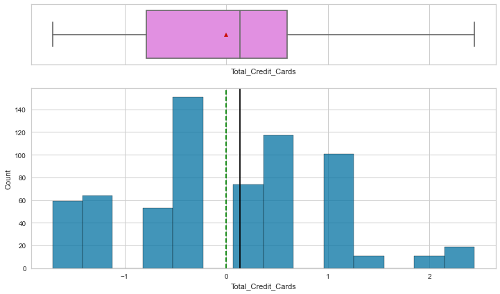

```python
histogram_boxplot(dfScaled, "Total_Credit_Cards")
```

#### Observations

- No outliers, as predicted
- Slightly left-skewed, but not significantly
- This data would look better in a bar plot

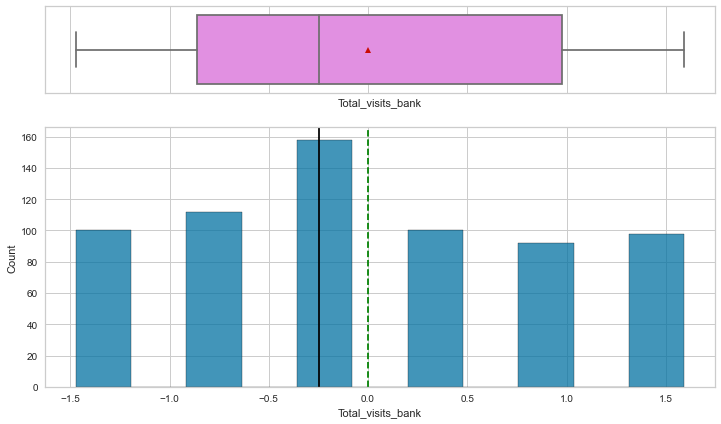

```python
histogram_boxplot(dfScaled, "Total_visits_bank")
```

#### Observations

- No outliers, as predicted
- Slightly right-skewed, although not significantly
- This data would look better in a bar plot

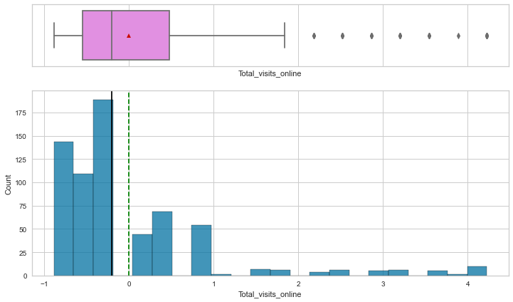

```python
histogram_boxplot(dfScaled, "Total_visits_online")
```

#### Observations

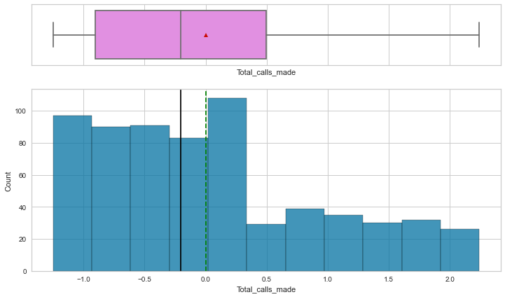

```python
histogram_boxplot(dfScaled, "Total_calls_made")
```

#### Observations

- No outliers, as predicted
- Slightly right-skewed, but not significantly
- This data would look better in a bar plot

```python
# Building a function to impute percentages into a bar plot
def bar_perc(plot, feature):
    total = len(feature) # length of the column
    for p in ax.patches:
        percentage = '{:.1f}%'.format(100 * p.get_height()/total)
        x = p.get_x() + p.get_width() / 2 - 0.05
        y = p.get_y() + p.get_height()
        ax.annotate(percentage, (x, y), size = 12)
```

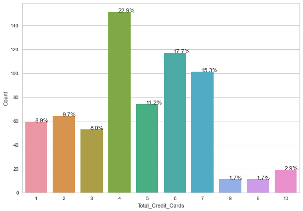

```python
# I will be running bar plots on my unscaled data so that the numbers make logical sense

plt.figure(figsize=(10,7))
ax = sns.countplot(df['Total_Credit_Cards'])
plt.xlabel('Total_Credit_Cards')
plt.ylabel('Count')
bar_perc(ax,df['Total_Credit_Cards'])
```

#### Observations

- Three major groups
- Most customers have 4-7 credit cards
- 1-3 is the next biggest group, followed by 8-10, which is the smallest group

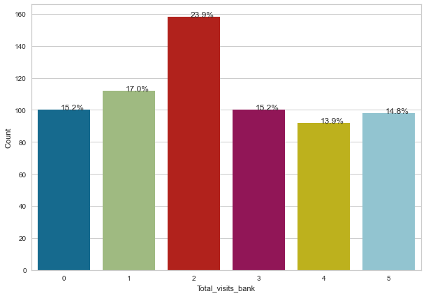

```python
plt.figure(figsize=(10,7))
ax = sns.countplot(df['Total_visits_bank'])
plt.xlabel('Total_visits_bank')
plt.ylabel('Count')
bar_perc(ax,df['Total_visits_bank'])
```

#### Observations

- Most customers visited the bank two times, with one time in 2nd place
- 0 and 3 visits are tied
- More people did not visit the bank at all than visited 4 or 5 times

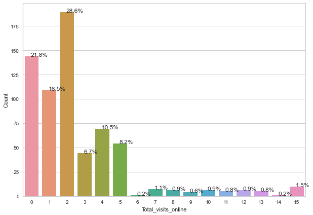

```python
plt.figure(figsize=(10,7))
ax = sns.countplot(df['Total_visits_online'])
plt.xlabel('Total_visits_online')
plt.ylabel('Count')
bar_perc(ax,df['Total_visits_online'])
```